# Microbiome data analysis using QIIME1

Dattatray S. Mongad[^1] and Nikeeta S. Chavan[^2]

28/04/2020

In this tutorial, of microbiome data analysis using OTU approach we have use QIIME1 (v1.9.1) (Caporaso et al. 2010)`, the installation guide is available at http://qiime.org/install/install.html. We have also used Microbiome Helper (https://github.com/LangilleLab/microbiome_helper/wiki) which has several scripts to automate QIIME1 workflow (Comeau, Douglas, and Langille 2017). We have used same data used for mothur MiSeq SOP(Kozich et al. 2013) available at http://www.mothur.org/w/images/d/d6/MiSeqSOPData.zip. This data is already demultiplexed but in some cases, sequences from different samples can be lumped together in single FASTQ file and each sample is labeled using barcodes (unique sequences for each sample). QIIME1 can work on both multiplexed or demultiplexed data, to show demultplexing we have used different dataset in first step.

#### Demultiplexing

To show how demultiplexing works using QIIME1 we have used sequences (illumina/forward_reads.fastq.gz), barcodes (illumina/barcodes.fastq.gz) and mapping file (illumina/map.tsv) available at ftp://ftp.microbio.me/qiime/tutorial_files/moving_pictures_tutorial-1.9.0.tgz derived from Moving Pictures of Human Microbiome study (Caporaso et al. 2011)`.Mapping file is important to tell which barcodes correspond to which samples. The first line (header) of mapping file starts with ‘#’ which have mandatory fields line ‘SampleID’, ‘BarcodeSequence’, ‘LinkerPrimerSequence’ and ‘Description’ with some optional metadata about each sample. The “SampleID” column must be unique to each sample and will be use to add labels in each sequence while demultiplexing. After generating mapping file, prior to demultiplexing one should validate it by using validate_mapping_file.py command.

```bash
#SampleID   BarcodeSequence LinkerPrimerSequence    SampleType  Description
L1S8    AGCTGACTAGTC    GTGCCAGCMGCCGCGGTAA gut 1_Fece_10_28_2008
L1S140  ATGGCAGCTCTA    GTGCCAGCMGCCGCGGTAA gut 2_Fece_10_28_2008
L1S57   ACACACTATGGC    GTGCCAGCMGCCGCGGTAA gut 1_Fece_1_20_2009
L1S208  CTGAGATACGCG    GTGCCAGCMGCCGCGGTAA gut 2_Fece_1_20_2009
L1S76   ACTACGTGTGGT    GTGCCAGCMGCCGCGGTAA gut 1_Fece_2_17_2009
L1S105  AGTGCGATGCGT    GTGCCAGCMGCCGCGGTAA gut 1_Fece_3_17_2009
L1S257  CCGACTGAGATG    GTGCCAGCMGCCGCGGTAA gut 2_Fece_3_17_2009
L1S281  CCTCTCGTGATC    GTGCCAGCMGCCGCGGTAA gut 2_Fece_4_14_2009
```

QIIME1 provides a script [split_libraries_fastq.py](http://qiime.org/scripts/split_libraries_fastq.html) for demultiplexing and quality filtering purpose which gives filtered sequences from each sample into single FASTA file which can be proceed for chimera removal and directly to OTU picking. Following command shows demultiplexing with minimum quality cut-off 20.

```bash
split_libraries_fastq.py -i forward_reads.fastq.gz -m map.tsv -b barcodes.fastq.gz -o slout -q 20
```

If you want manual inspection of quality of sequences from each sample, you can use fastq-multx to write sequences in separate FASTQ files. It requires same mapping file but with mandatory headers “id” and “seq”. Following is snapshot of mapping file and fastq-multx command for demultiplexing

```bash
id  seq LinkerPrimerSequence    SampleType  Description
L1S8    AGCTGACTAGTC    GTGCCAGCMGCCGCGGTAA gut 1_Fece_10_28_2008
L1S140  ATGGCAGCTCTA    GTGCCAGCMGCCGCGGTAA gut 2_Fece_10_28_2008
L1S57   ACACACTATGGC    GTGCCAGCMGCCGCGGTAA gut 1_Fece_1_20_2009
L1S208  CTGAGATACGCG    GTGCCAGCMGCCGCGGTAA gut 2_Fece_1_20_2009
L1S76   ACTACGTGTGGT    GTGCCAGCMGCCGCGGTAA gut 1_Fece_2_17_2009
L1S105  AGTGCGATGCGT    GTGCCAGCMGCCGCGGTAA gut 1_Fece_3_17_2009
L1S257  CCGACTGAGATG    GTGCCAGCMGCCGCGGTAA gut 2_Fece_3_17_2009
L1S281  CCTCTCGTGATC    GTGCCAGCMGCCGCGGTAA gut 2_Fece_4_14_2009
L2S240  CATATCGCAGTT    GTGCCAGCMGCCGCGGTAA left    palm    2_L_Palm_10_28_2008

#fastq-multx
fastq-multx -B map.tsv barcodes.fastq.gz forward_reads.fastq.gz -o n/a -o %.fastq

# for paired end data
fastq-multx -B map.tsv barcodes.fastq.gz forward_reads.fastq.gz reverse_reads.fastq.gz -o n/a -o %_R1.fastq -o %_R2.fastq
```

Now, we assume that we have demultiplexed FASTQ files, we will procedd for merging paired end reads and do some quality filtering using our MiSeq SOP data.

### 1. Merging paired-end reads, quality analysis and filtering

First we have to merge/stitch paired-end reads. We will run PEAR: a fast and accurate paired-end read merger for stitching paired-end reads (Zhang et al. 2014)` using *‘run_pear.pl’* script from microbiome helper. This script assumes that paired-end files have same name with “_R1” in forward and “_R2” in reverse read filename.

```bash
# change directory to path where fastq files are located
cd MiSeq_SOP
run_pear.pl -p 4 -o stitched_reads *.fastq
```

Now we will inspect the quality of each assembled read using FASTQC which is simplest tool to visualize quality of each sequence through variety of charts. We will run FASTQC on every FASTQ file, we have shown per base quality of forward and reverse reads of sample “F3D0_S188_L001” and “F3D1_S189_L001”

```bash
fastqc -t 4 stitched_reads/*.assembled.fastq
```

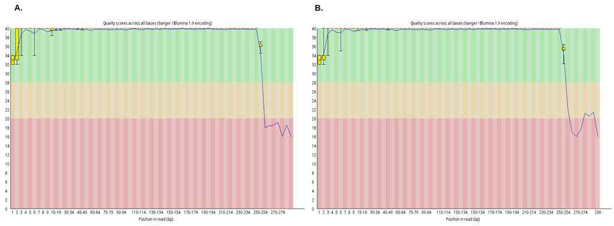

```bash
read_filter.pl -q 20 -p 90 -l 250 --primer_check none --thread 4 stitched_reads/*.assembled.* -b /path_to_bbmap
```

Here, we have used Q20 quality cut-off with minimum length of reads to be 250. “-p 90” specifies that 90% of bases from reads should have minimum quality cut-off (>=Q20) to qualify the read.

### 2. Chimera removal

```bash
# convert FASTQ files to FASTA
run_fastq_to_fasta.pl -p 4 -o fasta_files filtered_reads/*fastq

#Remove chimeric sequences from each samples
chimera_filter.pl --thread 4 -type 1 -db  gg_13_8_otus/rep_set/97_otus.fasta fasta_files/*
```

Here we have used [Greengenes](https://greengenes.secondgenome.com/?prefix=downloads/greengenes_database/gg_13_5/) database but you can use any reference data provided FASTA file. Now, we have to merge all sequences from different samples into single FASTA files with sampleIDs present in headers of each sequences. *‘add_qiime_labels.py’* requires a mapping file to specify sampleIDs to each FASTA file. *‘create_qiime_map.pl’* from microbiome helper package can create a mapping file with first column as sampleIDs and another “FileInput” column containing filenames.

```bash
create_qiime_map.pl non_chimeras/*.fasta >map.tsv

head map.tsv
#SampleID       BarcodeSequence LinkerPrimerSequence    FileInput
F3D0                    F3D0_S188_L001.assembled_filtered.nonchimera.fasta
F3D141                  F3D141_S207_L001.assembled_filtered.nonchimera.fasta
F3D142                  F3D142_S208_L001.assembled_filtered.nonchimera.fasta
F3D143                  F3D143_S209_L001.assembled_filtered.nonchimera.fasta
F3D144                  F3D144_S210_L001.assembled_filtered.nonchimera.fasta
F3D145                  F3D145_S211_L001.assembled_filtered.nonchimera.fasta
F3D146                  F3D146_S212_L001.assembled_filtered.nonchimera.fasta
F3D147                  F3D147_S213_L001.assembled_filtered.nonchimera.fasta
F3D148                  F3D148_S214_L001.assembled_filtered.nonchimera.fasta

add_qiime_labels.py -m map.tsv -i non_chimeras/ -c FileInput -o combined_seqs
```

This will generate a single FASTA file (combined_seqs.fna) inside output directory. This FASTA file format is similar to one generated using *‘split_libraries_fastq.py’* during demultiplexing. If you have proceed with demultiplexing step with this command then you can use ‘seqs.fna’ (which have sample Ids in headers already) file as it is for chimera removal by using following command.

```bash
vsearch --uchime_ref seqs.fna --db gg_13_8_otus/rep_set/97_otus.fasta –nonchimeras combined_fasta.fna
```

### 3. OTU picking strategies

OTU picking is process of clustering similar sequences (using percent identity cut-off) in a single unit called as Operational Taxonomic Unit. For clustering, QIIME1 wraps external tools including uclust (Edgar 2010). QIIME1 provides three different OTU-picking strategies which are demonstrated below. User can choose any of the three OTU picking strategies depending on the aim of study. We have demonstrated and discussed each of them briefly using default percent identity cut-off (97%) however, one can find more information at http://qiime.org/tutorials/otu_picking.html.

#### 3.1 Closed reference

In closed-reference OTU-picking method, clustering is done against reference data set. Reads which are not similar to any reference sequence will be excluded from further analysis. This method can be used for large data sets as it can be run in parallel manner, this speeds up clustering process. ‘pick_closed_reference_otus.py’ script is used for closed-reference OTU-picking as follows:

```bash
pick_closed_reference_otus.py -i combined_seqs/combined_seqs.fna -o closed_ref_otus -s
```

Advantage of using this method is reliable taxonomic assignments as OTUs are already defined in reference data set collection. It can only be used for analyzing samples with known reference sequence collection to cluster against as it is unable to detect novel sequences from data.

#### 3.2 Denovo

In de novo OTU picking all sequences are compared with one another without any external reference database and clustered using given percent identity cut-off . ‘pick_de_novo_otus.py’ script is used for de-novo OTU picking as follows:

```bash
pick_de_novo_otus.py -i combined_seqs/combined_seqs.fna -o denovo_otus  -O 4 -a
```

This method is not preferred for large data as it can be time-consuming. It will be used when there is no reference clustering data set available. Advantage of using this method is that all reads from dataset will be clustered and used in further analysis.

#### 3.3 Open reference

Open-reference OTU picking method is combination of both reference-based and de-novo approaches for clustering. It uses closed reference approach for clustering of reads which map to reference dataset and denovo clustering method for reads which do not hit reference data sets. ‘pick_open_reference_otus.py’ script is used for open-reference OTU picking as follows:

```bash
pick_open_reference_otus.py -i combined_seqs/combined_seqs.fna -o open_ref_otus -m uclust
```

This method cannot be used with non-overlapping amplicons and presence of reference data set is required. With this method partial parallel processing can be done which speed up process as comapred to de-novo approach.